# N2138_9 exp

2023-07-19

More stringent clean-up of the raw datasets

```r
setwd("C:/Users/sandeh/OneDrive - Karolinska Institutet/Dokument/Generalprojectdocuments/Nodder 10x/July2023")
```

```r
library(Seurat)
```

```r
library(ggplot2)
library(sctransform)
library(scDblFinder)
library(SingleCellExperiment)
```

```r
N2234_2_data <- Read10X_h5("2234_2_filtered_feature_bc_matrix.h5")
N2234_2 <- CreateSeuratObject(counts = N2234_2_data)
N2234_2
```

```
## An object of class Seurat
## 32286 features across 7111 samples within 1 assay
## Active assay: RNA (32286 features, 0 variable features)
```

```r
N2234_2[["percent.mt"]] <- PercentageFeatureSet(N2234_2, pattern = "^mt-")
```

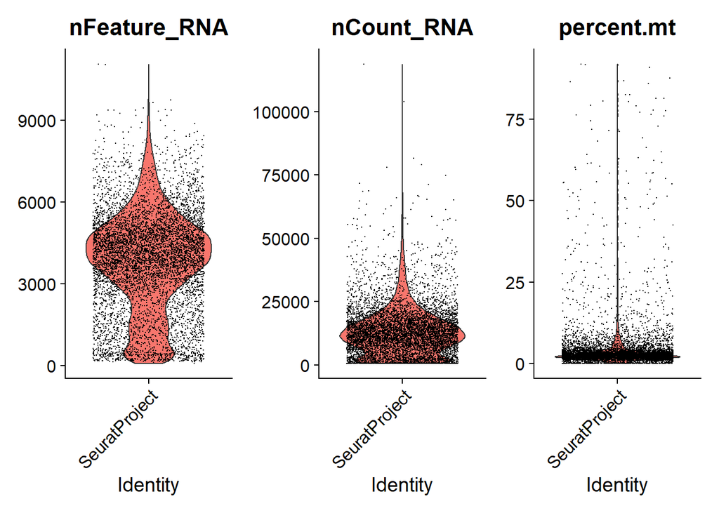

```r
VlnPlot(N2234_2, features = c("nFeature_RNA", "nCount_RNA", "percent.mt"), ncol = 3)
```

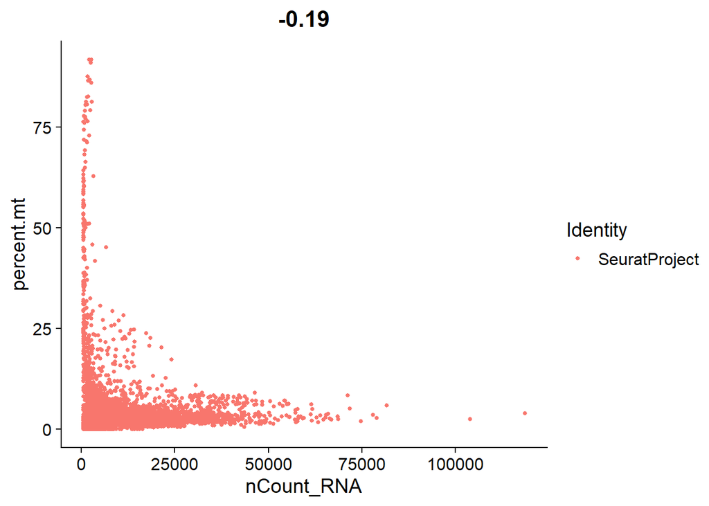

```r
FeatureScatter(N2234_2, feature1 = "nCount_RNA", feature2 = "percent.mt")
```

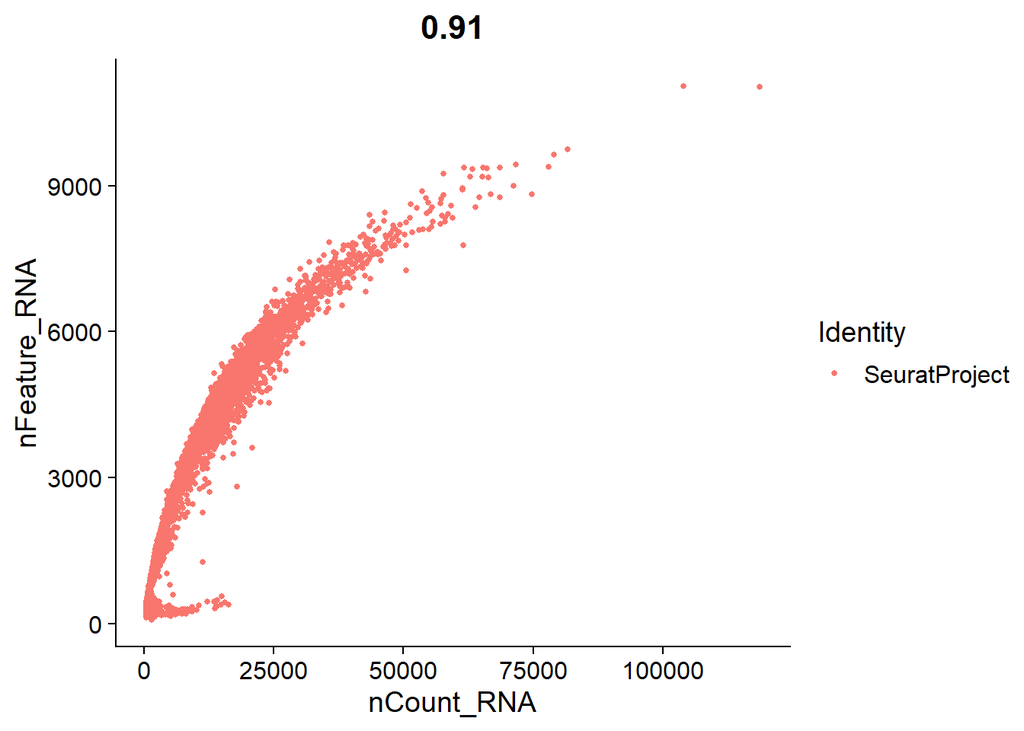

```r
FeatureScatter(N2234_2, feature1 = "nCount_RNA", feature2 = "nFeature_RNA")
```

Initial filtering, this dataset has slightly higher nCount max, so instead of using the max cutoff of 50.000 (as I did for the other datasets, I am starting with 75.000)

```r
N2234_2<- subset(N2234_2, subset = nCount_RNA <75000 & nFeature_RNA > 2000 & percent.mt <20)
```

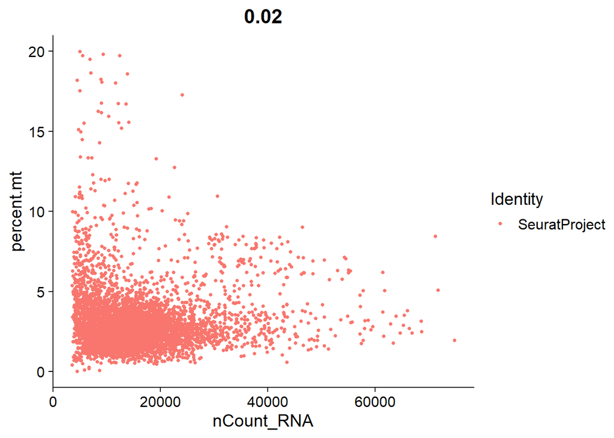

```r
FeatureScatter(N2234_2, feature1 = "nCount_RNA", feature2 = "percent.mt")
```

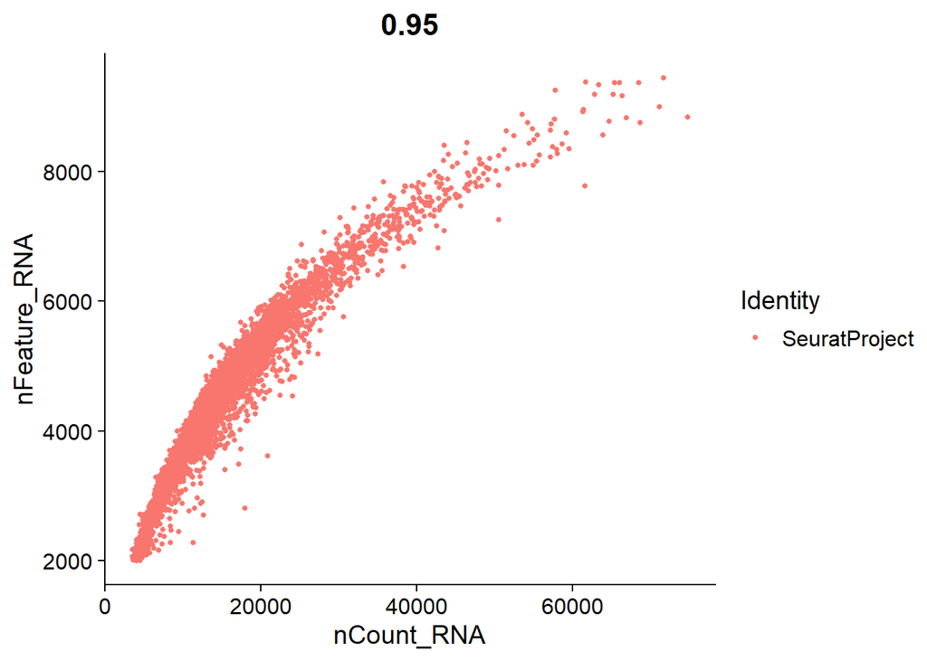

```r
FeatureScatter(N2234_2, feature1 = "nCount_RNA", feature2 = "nFeature_RNA")
```

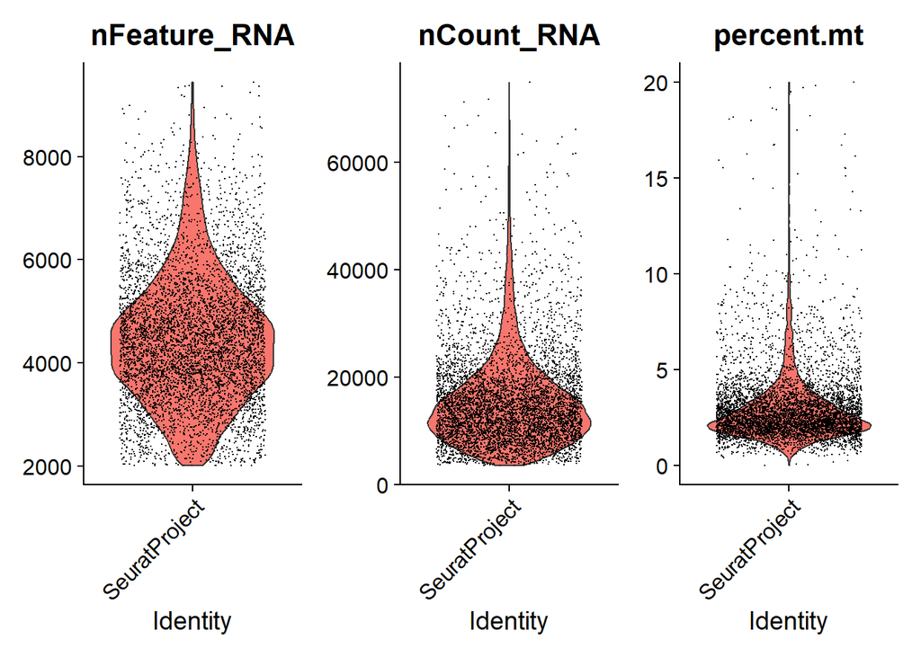

```r
VlnPlot(N2234_2, features = c("nFeature_RNA", "nCount_RNA", "percent.mt"), ncol = 3)
```

I will filter more stringently, also the 50.000 count cut off and 10% percent.mt

```r
N2234_2 <- subset(N2234_2, subset = nCount_RNA <50000 & nFeature_RNA > 2000 &percent.mt <10)
```

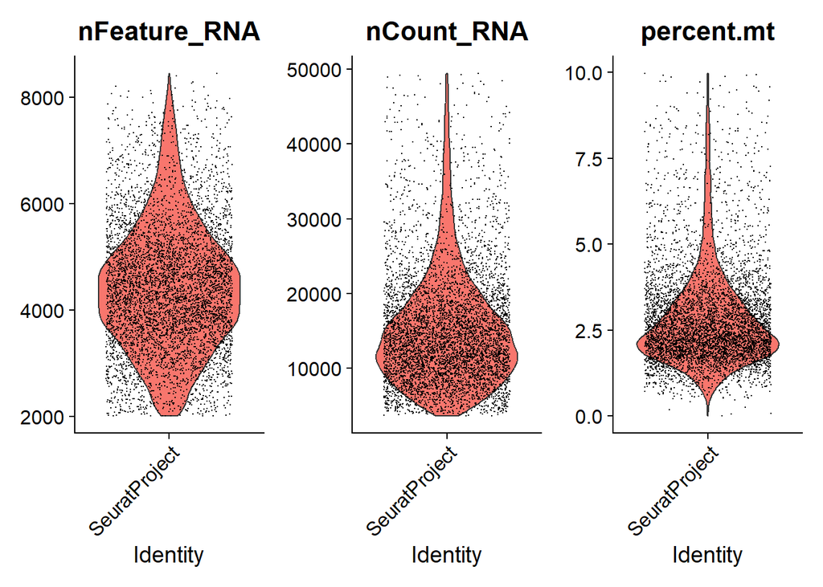

```r
VlnPlot(N2234_2, features = c("nFeature_RNA", "nCount_RNA", "percent.mt"), ncol = 3)
```

Lets normalise the data using SCTransform V2, with regression of percent.mt

```r
N2234_2<- SCTransform(N2234_2, vst.flavor = "v2", vars.to.regress = "percent.mt")
```

```
## vst.flavor='v2' set, setting model to use fixed slope and exclude poisson genes.
```

```
## Calculating cell attributes from input UMI matrix: log_umi
```

```
## Total Step 1 genes: 21847
```

```
## Total overdispersed genes: 19665
```

```
## Excluding 2182 genes from Step 1 because they are not overdispersed.
```

```
## Variance stabilizing transformation of count matrix of size 22120 by 5682
```

```
## Model formula is y ~ log_umi
```

```
## Get Negative Binomial regression parameters per gene
```

```
## Using 2000 genes, 5000 cells
```

```
## Setting estimate of  19 genes to inf as theta_mm/theta_mle < 1e-3
```

```
## # of step1 poisson genes (variance < mean): 0
```

```
## # of low mean genes (mean < 0.001): 325
```

```
## Total # of Step1 poisson genes (theta=Inf; variance < mean): 19
```

```
## Total # of poisson genes (theta=Inf; variance < mean): 2389
```

```
## Calling offset model for all 2389 poisson genes
```

```
## Found 38 outliers - those will be ignored in fitting/regularization step
```

```
## Ignoring theta inf genes
```

```
## Replacing fit params for 2389 poisson genes by theta=Inf
```

```
## Setting min_variance based on median UMI:  0.04
```

```
## Second step: Get residuals using fitted parameters for 22120 genes
```

```
## Computing corrected count matrix for 22120 genes
```

```
## Wall clock passed: Time difference of 1.276807 mins
```

```
## Determine variable features
```

```
## Place corrected count matrix in counts slot
```

```
## Centering data matrix
```

```
## Set default assay to SCT
```

```r
N2234_2 <- RunPCA(N2234_2, verbose = FALSE)
```

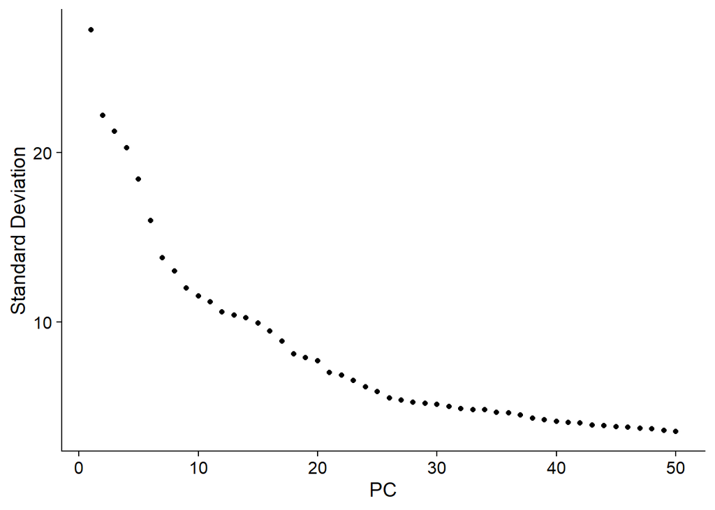

```r
ElbowPlot(N2234_2, ndims = 50)
```

Before I overclustered the datasets a bit, but for this initial filtering I am only interested in getting out the Epcam+ clusters, so I am not clustering at max settings, but at 30 for now

```r
N2234_2 <- FindNeighbors(N2234_2, dims = 1:30, verbose = FALSE)
N2234_2 <- FindClusters(N2234_2, verbose = FALSE)
N2234_2 <- RunUMAP(N2234_2, dims = 1:30, verbose = FALSE)
```

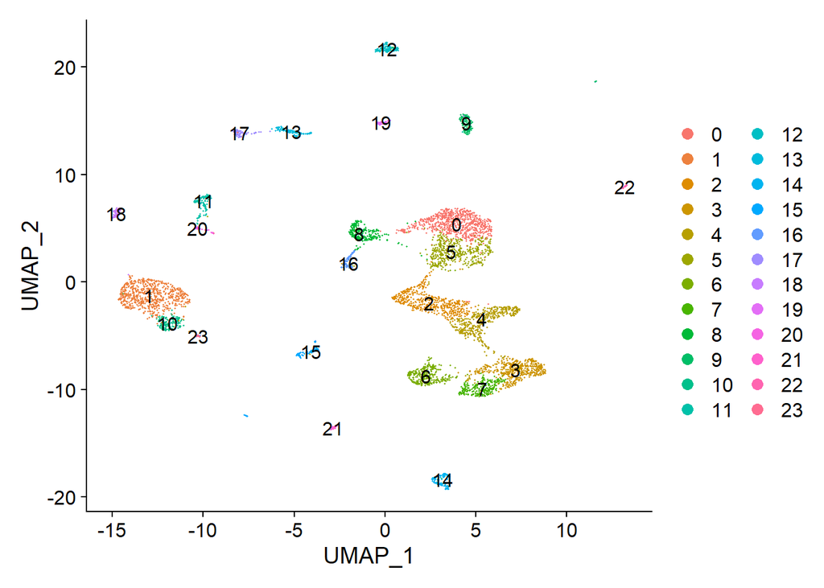

```r
DimPlot(N2234_2, label = TRUE)
```

```r
OCmarkers <- c("Epcam", "Sox2", "Myo7a", "Myo6", "Ccer2", "Otof", "Fgf8", "Ocm", "Pou4f3", "Fabp7", "S100a1", "Hey2", "Npy", "Mansc4", "Oc90")
```

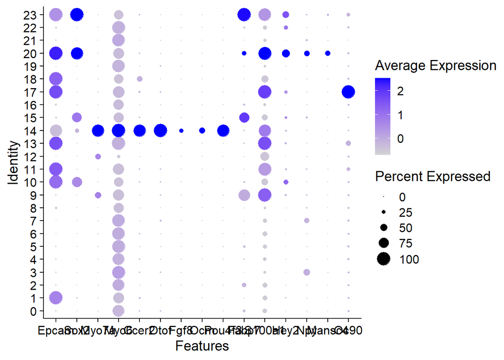

```r
DotPlot(N2234_2, features = OCmarkers)
```

```r
DefaultAssay(N2234_2) <- "SCT"
```

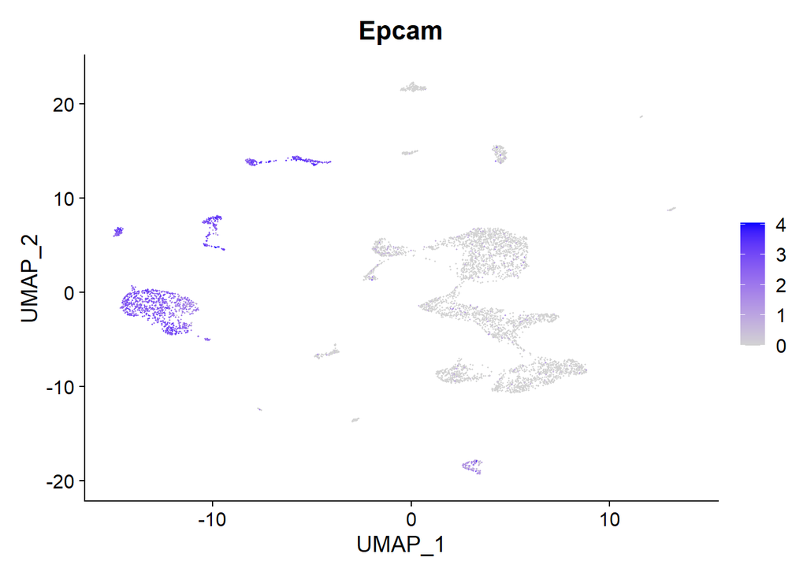

```r
FeaturePlot(N2234_2, features = c("Epcam"))
```

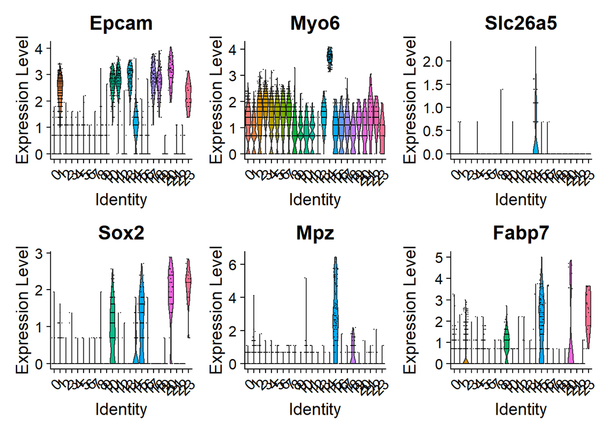

```r
VlnPlot(N2234_2, features = c("Epcam", "Myo6", "Slc26a5", "Sox2", "Mpz", "Fabp7"))
```

Clusters of interest are, Epcam and Myo6 (Sox2+, Epcam- clusters are glia, not including glia right now) : 1, 10, 11, 13, 14, 17, 18, 20, 23

But first I will remove the doublets.

```r
sce <- as.SingleCellExperiment(N2234_2)
sce <- scDblFinder(sce)
```

```
## Creating ~5000 artificial doublets...
```

```
## Dimensional reduction
```

```
## Evaluating kNN...
```

```
## Training model...
```

```
## iter=0, 539 cells excluded from training.
```

```
## iter=1, 402 cells excluded from training.
```

```
## iter=2, 359 cells excluded from training.
```

```
## Threshold found:0.386
```

```
## 205 (3.6%) doublets called
```

```r
sce_seurat <- as.Seurat(sce)
```

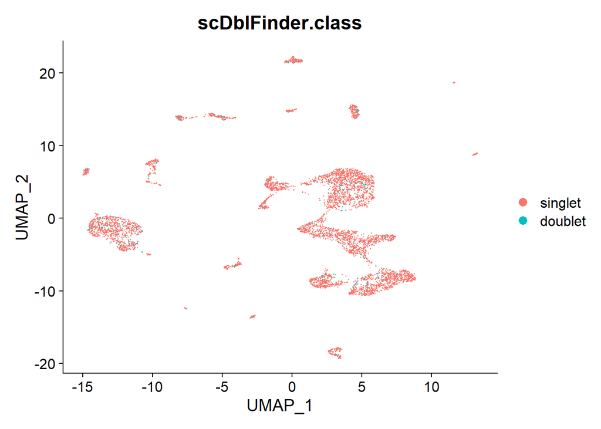

```r
DimPlot(sce_seurat, group.by = "scDblFinder.class")
```

```r
Idents(sce_seurat) <- "scDblFinder.class"
```

```r
N2234_2 <- subset(sce_seurat, scDblFinder.class == "singlet")
```

Lets subset to Epcam+ clusters as indicated above

```r
Idents(N2234_2) <- "seurat_clusters"
```

```r
N2234_2_QC <- subset(N2234_2, idents= c("1", "10", "11", "13", "14", "17", "18", "20", "23"))
```

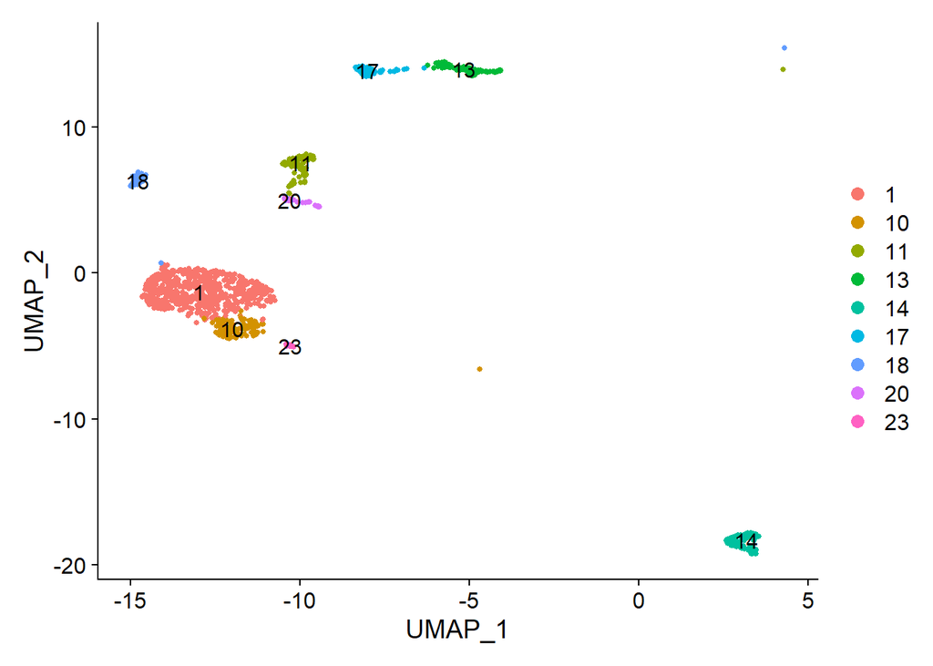

```r
DimPlot(N2234_2_QC, label = TRUE)
```

```r
N2234_2_QC
```

```
## An object of class Seurat
## 54406 features across 1336 samples within 2 assays
## Active assay: RNA (32286 features, 0 variable features)
##  1 other assay present: SCT
##  2 dimensional reductions calculated: PCA, UMAP
```

I am removing the dimensional reductions previously calculated, because it cannot overwrite and will name it umap instead of UMAP, but the default used for visualisation will be UMAP unless other specified. Maybe this causes issues later also during integration?

```r
N2234_2_QC[["PCA"]] <- NULL
N2234_2_QC[["UMAP"]] <- NULL
```

```r
N2234_2_QC
```

```
## An object of class Seurat
## 54406 features across 1336 samples within 2 assays
## Active assay: RNA (32286 features, 0 variable features)
##  1 other assay present: SCT
```

```r
N2234_2_QC <- SCTransform(N2234_2_QC, vst.flavor = "v2", vars.to.regress = "percent.mt")
```

```
## vst.flavor='v2' set, setting model to use fixed slope and exclude poisson genes.
```

```
## Calculating cell attributes from input UMI matrix: log_umi
```

```
## Total Step 1 genes: 18899
```

```
## Total overdispersed genes: 16708
```

```
## Excluding 2191 genes from Step 1 because they are not overdispersed.
```

```
## Variance stabilizing transformation of count matrix of size 18899 by 1336
```

```
## Model formula is y ~ log_umi
```

```
## Get Negative Binomial regression parameters per gene
```

```
## Using 2000 genes, 1336 cells
```

```
## Setting estimate of  20 genes to inf as theta_mm/theta_mle < 1e-3
```

```
## # of step1 poisson genes (variance < mean): 0
```

```
## # of low mean genes (mean < 0.001): 0
```

```
## Total # of Step1 poisson genes (theta=Inf; variance < mean): 20
```

```
## Total # of poisson genes (theta=Inf; variance < mean): 2191
```

```
## Calling offset model for all 2191 poisson genes
```

```
## Found 56 outliers - those will be ignored in fitting/regularization step
```

```
## Ignoring theta inf genes
```

```
## Replacing fit params for 2191 poisson genes by theta=Inf
```

```
## Setting min_variance based on median UMI:  0.16
```

```
## Second step: Get residuals using fitted parameters for 18899 genes
```

```
## Computing corrected count matrix for 18899 genes
```

```
## Wall clock passed: Time difference of 16.3289 secs
```

```
## Determine variable features
```

```
## Place corrected count matrix in counts slot
```

```
## Centering data matrix
```

```
## Set default assay to SCT
```

```r
N2234_2_QC <- RunPCA(N2234_2_QC)
```

```
## PC_ 1
## Positive:  Nrxn3, Ctnnd2, Calb1, Tnc, Rims2, Rbm24, Myo3a, Kcnh7, Thsd7b, Adgrv1
##     Ptprq, Grxcr1, Ankfn1, Ush2a, Smpx, Otof, Dscaml1, Gabrb3, Sema5b, Galnt13
##     Tmem178b, Srrm4, Loxhd1, Apba1, Kcnmb2, Tmem255b, Mob3b, Runx1t1, Dpp6, Espn
## Negative:  Dclk1, Gas2, Ptgds, Lrp2, Ror1, Enpep, Igf1, Lmx1a, S100b, Itpr1
##     Meis1, Wfdc2, Cacna2d1, Lrpap1, Frem1, Itgb5, Mt1, Dbi, Kcnq1, Gpx3
##     Rspo3, Mt3, Neat1, Kctd8, Washc3, Ehd3, Rnf152, Fam20a, Ccdc3, Kcne1
## PC_ 2
## Positive:  S100a1, Gas2, Dach1, Ror1, Ptgds, Lmx1a, Dclk1, Fut9, Meis1, Efna5
##     Naaladl2, Enpep, Frem1, Dach2, Fam20a, Dpysl3, Chchd10, Cryab, Cacnb2, Prkg1
##     Meis2, Ppp2r2b, Dpp10, Plce1, Cacna2d1, S100b, Sptssa, Epha5, Hist1h2bc, Tpm1
## Negative:  Clu, Itga8, Robo2, Sgcz, Ecrg4, Slit2, Cdh4, Tecta, Trpm3, Epyc
##     Zfp804b, Thrb, Spock1, Ldb2, Mia, Tmem117, Fras1, Syt1, Adgrg2, Zdhhc14
##     Ebf1, Ptn, Pcolce2, Fstl1, Tnfrsf19, Prdm16, Srgap1, Zfp521, Col2a1, Brinp1
## PC_ 3
## Positive:  Slc12a2, Lrp2, Clu, Cacnb2, Igf1, Pla2g7, Rspo3, Dnase1, Stac, Kcne1
##     Cdh4, Sgcz, Slit2, Sparcl1, Washc3, Esrrb, Ehd3, Spp1, Aldh1a2, Calb1
##     Erc1, Cdkl1, Hspa4l, Robo2, Calca, Mt3, Hgf, Zfp804b, Gpx3, Itga8
## Negative:  Pgm5, Prss23, Lgr5, Itga9, Nkain2, Prkg1, Zbtb20, Vim, Tshz2, Apoe
##     Thbs1, Otol1, Socs2, Scg2, Nalcn, Itgbl1, Pde4b, Slc26a4, Adgrl3, Fxyd6
##     Nupr1, Rgs6, Rbms3, Me3, Cntn5, Gulp1, Brip1, App, Irx3, Igfbp5
## PC_ 4
## Positive:  Tectb, Sox2, Nckap5, Igfbp3, Cpa6, Jag1, Cyp26b1, Fbn2, Adgrg6, Kcnb2
##     Hs6st2, Tenm4, Lsamp, Slitrk6, Ppp2r2b, Tecta, Sorbs2, Mast4, Ephb1, Fat3
##     Nrcam, Frmd4a, Cdkn1b, Ptprg, Gpc6, Lockd, Kremen1, Rorb, Ebf1, Ebf3
## Negative:  Epyc, Negr1, Plxdc2, Galnt7, Lum, Cnmd, Nebl, Apoe, Tshz2, Rbms3
##     Arl4c, Fxyd6, Scg2, Stard13, Slc26a4, Lmx1a, Col1a2, Fgf9, Gas1, Cadm2
##     Krt19, Ltbp1, Nkain2, Adamtsl1, Cdkn1c, Tmem132c, Pde4b, Irx3, Sgcd, Mme
## PC_ 5
## Positive:  Oc90, Erbb4, Vmo1, Postn, Cndp2, Dapl1, Zfpm2, Nkain3, Grid2, Stim2
##     Kctd8, Slc26a7, Dkk2, Crhbp, A930003A15Rik, Slc6a15, Ptprz1, Rnase4, Cacna1c, Rnase1
##     Sulf1, Sptlc3, Ap1s2, Gng2, Nlgn1, Otx2, Gm29266, Lypd2, Tmem72, Lrp2
## Negative:  Rasgef1b, Lum, Vim, Adgra3, Prss23, Dbi, Scg2, Car12, Negr1, Fxyd6
##     Map1b, Pgm5, Irx3, Nupr1, Lgals1, Lgr5, Itm2b, Brip1, Galnt7, Epyc
##     Pde4b, Tanc2, Stk39, Itgbl1, Col1a2, Irx5, Cdo1, Iqgap2, Dpp10, S100b
```

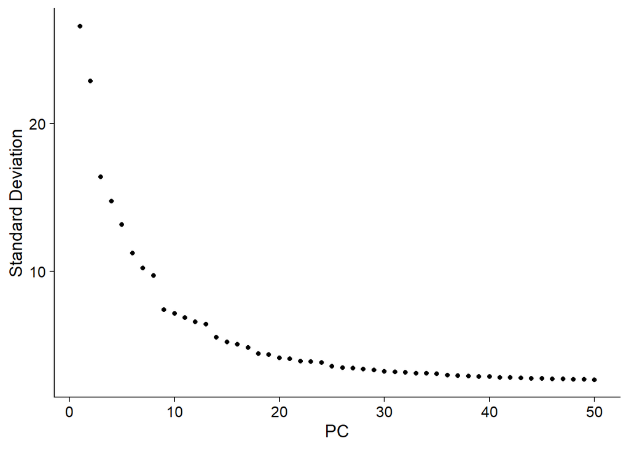

```r
ElbowPlot(N2234_2_QC, ndims = 50)
```

```r
N2234_2_QC <- FindNeighbors(N2234_2_QC, dims = 1:30)
N2234_2_QC <- FindClusters(N2234_2_QC)
```

```
## Modularity Optimizer version 1.3.0 by Ludo Waltman and Nees Jan van Eck
##
## Number of nodes: 1336
## Number of edges: 38793
##
## Running Louvain algorithm...
## Maximum modularity in 10 random starts: 0.8511
## Number of communities: 13
## Elapsed time: 0 seconds
```

```r
N2234_2_QC <- RunUMAP(N2234_2_QC, dims = 1:30)
```

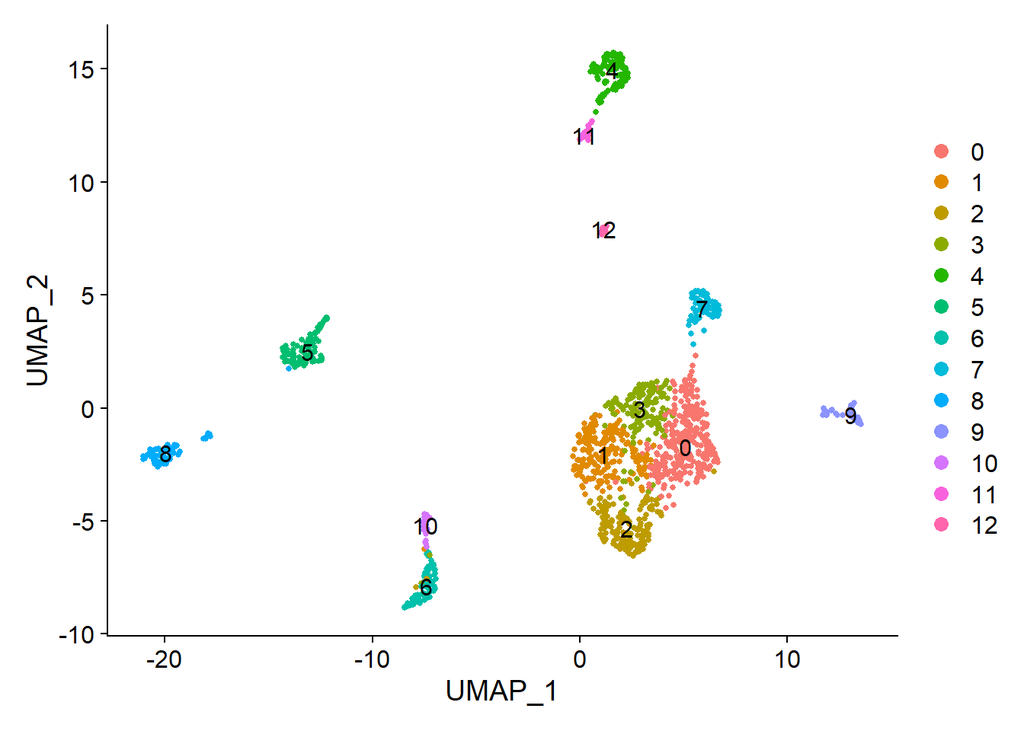

```r
DimPlot(N2234_2_QC, label = TRUE)
```

```r
DefaultAssay(N2234_2_QC) <- "SCT"
```

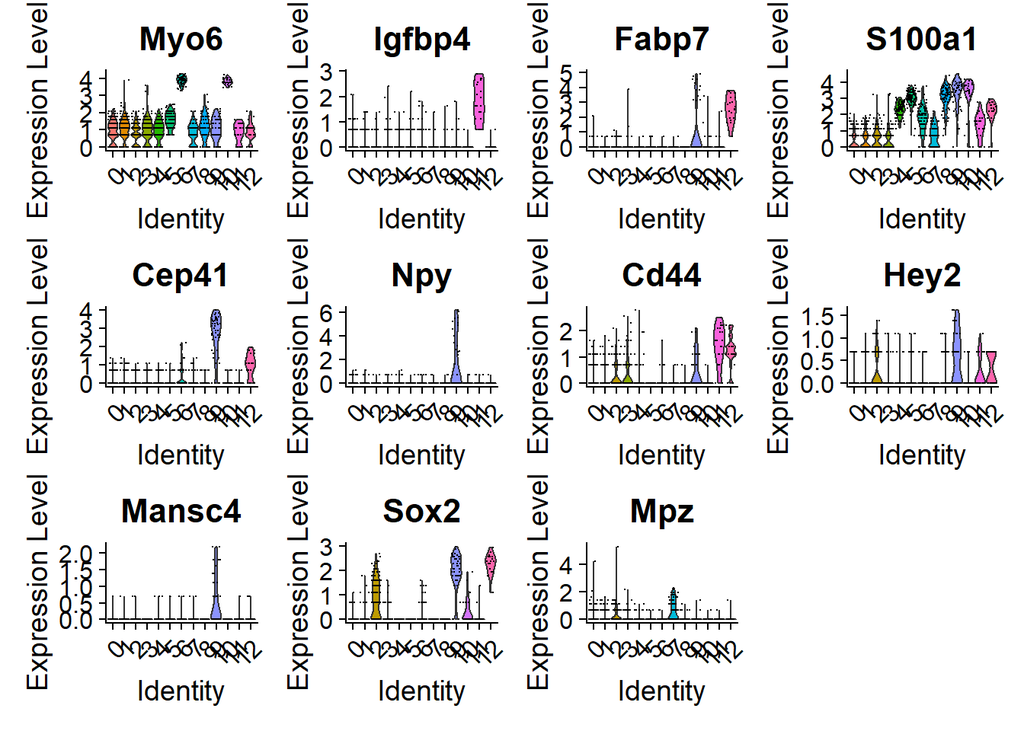

```r
VlnPlot(N2234_2_QC, features = c("Myo6", "Igfbp4", "Fabp7", "S100a1", "Cep41", "Npy", "Cd44", "Hey2", "Mansc4", "Sox2", "Mpz"))
```

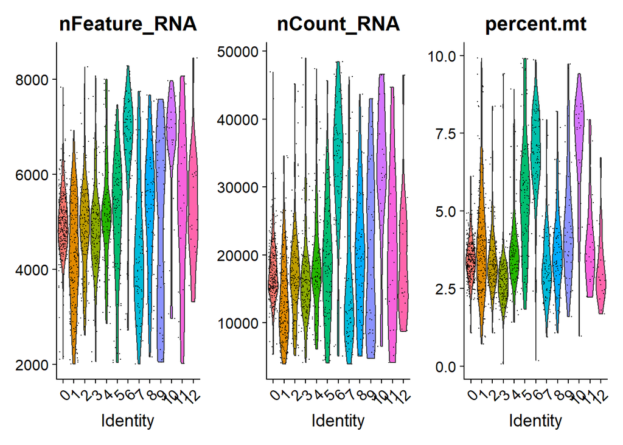

```r
VlnPlot(N2234_2_QC, features = c("nFeature_RNA", "nCount_RNA", "percent.mt"), ncol = 3)
```

Looks good

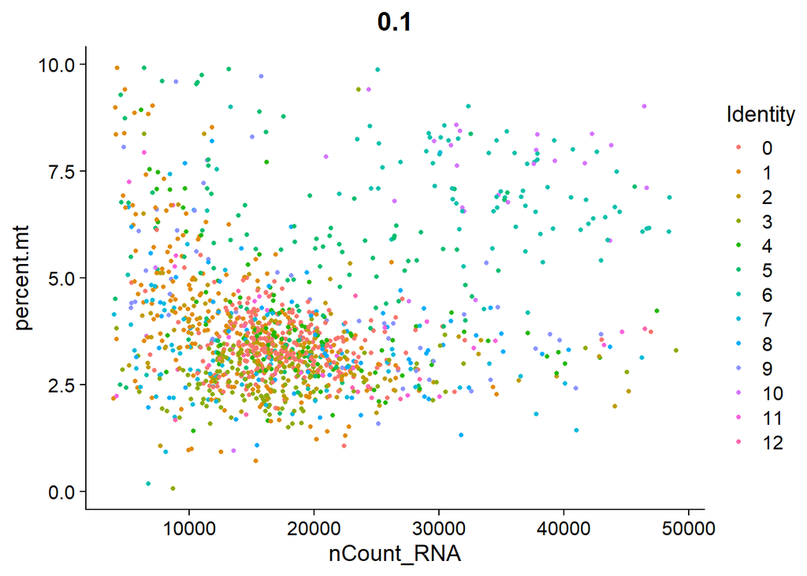

```r
FeatureScatter(N2234_2_QC, feature1 = "nCount_RNA", feature2 = "percent.mt")
```

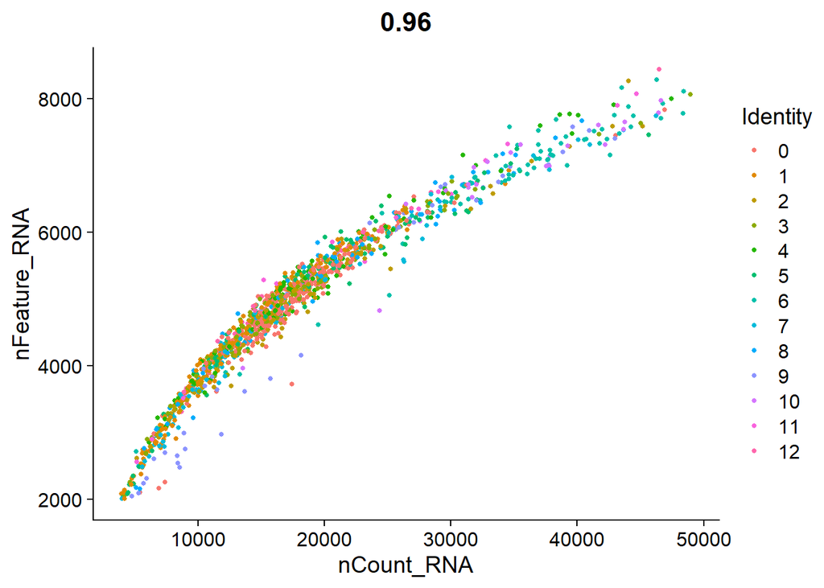

```r
FeatureScatter(N2234_2_QC, feature1 = "nCount_RNA", feature2 = "nFeature_RNA")
```

```r
saveRDS(N2234_2_QC, file = "N2234_2_QC.RDS")
```